# Introduction to the humcap package

Salfo Bikienga

2015-09-08

The humcap package provides functions for computing estimates of human capital premiums. The estimated capital premiums can then be used to compute human capital stocks. The package is written to make the replication of the “Human Capital Measurement: A Quantiles Regression Approach” paper easy.

## Installing the package

The package is in github repository. You will need the devtools package to install packages from github. To install the devtool package, run, after uncommenting it, the following line of code:

```r
#install.packages("devtools")
```

Then install the humcap package as follows:

```r
#devtools::install_github("Salfo/humcap")
library(humcap) # load the package
```

The package has essentially two main functions. The hum_cap() function and the mult_hum_cap() function. The hum_cap() function takes a dataset and compute a single human capital premium estimate. The package comes with a dataset. The dataset is the current population survey data from 1990 to 2013, tellingly named cps1990_2013.

```r
data(cps1990_2013)
str(cps1990_2013) # look at what is in the dataset
```

```
## Classes 'tbl_df', 'tbl' and 'data.frame':    1618172 obs. of  23 variables:
##  $ statefip: Factor w/ 75 levels "Alabama","Alaska",..: 20 20 20 20 20 20 20 20 20 20 ...
##  $ year    : int  1990 1990 1990 1990 1990 1990 1990 1990 1990 1990 ...
##  $ age     : Factor w/ 100 levels "Under 1 year",..: 63 49 46 33 31 53 42 41 32 28 ...
##  $ age1    : num  62 48 45 32 30 52 41 40 31 27 ...
##  $ sex     : Factor w/ 3 levels "Male","Female",..: 2 1 2 1 2 2 1 2 1 2 ...
##  $ race    : Factor w/ 29 levels "White","Black/Negro",..: 1 1 1 1 1 1 1 1 1 1 ...
##  $ race1   : Factor w/ 2 levels "White","Non_White": 1 1 1 1 1 1 1 1 1 1 ...
##  $ educ    : Factor w/ 36 levels "NIU or no schooling",..: 16 14 22 28 28 22 28 28 28 24 ...
##  $ educ1   : num  10 8 13 16 16 13 16 16 16 14 ...
##  $ educ2   : Factor w/ 5 levels "LHSC","HSD","Asso",..: 1 1 2 4 4 2 4 4 4 3 ...
##  $ marst   : Factor w/ 7 levels "Married, spouse present",..: 4 1 1 1 1 4 1 1 1 1 ...
##  $ marst1  : Factor w/ 2 levels "Non_Married",..: 1 2 2 2 2 1 2 2 2 2 ...
##  $ exp     : num  46 34 26 10 8 33 19 18 9 7 ...
##  $ exp_sq  : num  2116 1156 676 100 64 ...
##  $ uhrswork: Factor w/ 100 levels "niu","1 hour",..: 21 51 26 61 37 25 51 8 41 21 ...
##  $ hourwage: int  9999 9999 9999 9999 9999 9999 9999 9999 9999 9999 ...
##  $ incwage : int  2288 31000 9700 60000 30000 5000 72300 2000 24000 5200 ...
##  $ earnweek: int  0 0 0 0 0 0 0 0 0 0 ...
##  $ hrswage : num  2.2 11.92 7.46 19.23 16.03 ...
##  $ lhrswage: num  0.788 2.478 2.01 2.957 2.774 ...
##  $ hrsw    : num  1040 2600 1300 3120 1872 ...
##  $ wtsupp  : num  573 604 604 674 674 ...
##  $ state   : Factor w/ 51 levels "Alabama","Alaska",..: 20 20 20 20 20 20 20 20 20 20 ...
```

Let’s subset the data to explore the function hum_cap(). Again, this function takes a dataset and returns estimates of human capital premium for male female, and All, that is the combined for male and female.

```r
library(dplyr) # dplyr is needed for data subsetting
testdata <- filter(cps1990_2013, state == "Nebraska", year == 2013)
```

The subsetted data is the data for Nebraska, 2013.

```r
lin<-lhrswage~educ2+ exp + exp_sq + marst1 # define the model
testmod <- hum_cap(data= testdata, formula = lin, tau = 0.2, weights = testdata$wtsupp, FUN = lm)
testmod$hc.prem # output human capital premium
```

```
##     male   female      all
## 15.10466 12.37769 13.82013
```

Uncomment the following code to see the full output of the function.

```r
# testmod
```

Note that the argument FUN takes the lm() function. To use quantile regression estimations, replace the FUN argument lm with rq. However, for the rq function to work, we need to load the quantreg package.

```r
require(quantreg) # load the quantreg package
testmod1 <- hum_cap(data= testdata, formula = lin, tau = 0.2, weights = testdata$wtsupp, FUN = rq)
testmod1$hc.prem # output human capital premium
```

```
##     male   female      all
## 17.04517 14.50954 15.85077
```

To run the hum_cap() function for multiple years, and multiple states, the mult_hum_cap() function is handy. Uncomment the following to try the fuction. Play around with the function by changing some of its arguments.

The function throws warnings messages that can be safely ignored. These warnings are ineherant to the rq() function if FUN takes rq, or the tau argument if FUN take lm.

```r
#testmod11 <- mult_hum_cap(data= cps1990_2013, formula = lin, tau = 0.2,
#weights = testdata$wtsupp, FUN = rq, begin = 2011, end = 2013)
#testmod11 # print output
```

Note that the above code takes time to excecute. That should be expected, since the estimations are done for several states.

## Additional functions

The package provides additional functions for post processing the estimates.

### RealValueConverter() function

The RealValueConverter() function converts the estimates (nominal values) into real values. The default of the function is the 2013 dollar value. To allow you to try the additional functions, the package provides the estimates of the preinstalled data. These estimates are named testmod2.

```r
data(testmod2) # load precomputed estimates of human capital premiums
str(testmod2) # see what is in testmod2
```

```
## List of 3
##  $ All   : num [1:51, 1:24] 7.33 10.9 8.62 6.88 9.92 ...
##   ..- attr(*, "dimnames")=List of 2
##   .. ..$ : chr [1:51] "Alabama" "Alaska" "Arizona" "Arkansas" ...
##   .. ..$ : chr [1:24] "1990" "1991" "1992" "1993" ...
##  $ Male  : num [1:51, 1:24] 9.48 13.09 10.34 8.24 11.9 ...
##   ..- attr(*, "dimnames")=List of 2
##   .. ..$ : chr [1:51] "Alabama" "Alaska" "Arizona" "Arkansas" ...
##   .. ..$ : chr [1:24] "1990" "1991" "1992" "1993" ...
##  $ Female: num [1:51, 1:24] 4.96 8.23 6.51 5.48 7.46 ...
##   ..- attr(*, "dimnames")=List of 2
##   .. ..$ : chr [1:51] "Alabama" "Alaska" "Arizona" "Arkansas" ...
##   .. ..$ : chr [1:24] "1990" "1991" "1992" "1993" ...
```

```r
head(testmod2[[1]][,1:6]) # print out few estimates (Nominal values)
```

```
##                 1990      1991      1992      1993      1994      1995
## Alabama     7.331413  7.231815  7.596281  8.436302  8.567241  9.372878
## Alaska     10.902549 10.638366 11.134103 11.617920 11.766019 13.342978
## Arizona     8.617152  8.146037  8.249965  9.028815  9.743704 10.821017
## Arkansas    6.881444  6.266025  7.186487  7.721253  7.090874  7.254074
## California  9.923135 10.281333 10.389423 10.728016 11.103102 11.397568
## Colorado    9.146560  9.279052  7.945691  9.814502 11.607394 10.674961
```

To use the `RealValueConverter()` function, you need to provide (1) the dataset to be converted, (2) a vector of cpi_index, (3) the index value, which is the cpi value for the base year; and (4) the beginning and ending years. Make sure to read the section CPI Data below.

```r
real_values <- RealValueConverter(df = testmod2[[1]], cpi = cpi_Ind, index = 232.957, begin = 1990,
                        end = 2013)
head(real_values[,1:6]) # print out few estimates (Real values)
```

```
##                1990     1991     1992     1993     1994     1995
## Alabama    13.06736 12.36932 12.61302 13.60066 13.46693 14.32728
## Alaska     19.43248 18.19590 18.48729 18.72994 18.49512 20.39593
## Arizona    15.35903 13.93301 13.69841 14.55589 15.31622 16.54089
## Arkansas   12.26534 10.71743 11.93259 12.44789 11.14621 11.08850
## California 17.68679 17.58523 17.25081 17.29527 17.45307 17.42220
## Colorado   16.30264 15.87093 13.19319 15.82254 18.24577 16.31763
```

```r
# Another example using RealValueConverter(). Note the changes in ending date
head(RealValueConverter(df = testmod2[[1]][,1:6], begin = 1990, end = 1995))
```

```
##                1990     1991     1992     1993     1994     1995
## Alabama    13.06736 12.36932 12.61302 13.60066 13.46693 14.32728
## Alaska     19.43248 18.19590 18.48729 18.72994 18.49512 20.39593
## Arizona    15.35903 13.93301 13.69841 14.55589 15.31622 16.54089
## Arkansas   12.26534 10.71743 11.93259 12.44789 11.14621 11.08850
## California 17.68679 17.58523 17.25081 17.29527 17.45307 17.42220
## Colorado   16.30264 15.87093 13.19319 15.82254 18.24577 16.31763
```

### smoother3() function

The smoother3() function produces a three year moving average estimates.

```r
smooth_data <- smoother3(testmod2$All)
head(smooth_data[,1:6])
```

```
##                 1991      1992      1993      1994      1995      1996
## Alabama     7.386503  7.754800  8.199942  8.792141  9.614909 10.126741
## Alaska     10.891673 11.130130 11.506014 12.242306 12.791095 12.691405
## Arizona     8.337718  8.474939  9.007495  9.864512 10.287827 10.459039
## Arkansas    6.777985  7.057922  7.332871  7.355400  7.452457  7.653872
## California 10.197964 10.466258 10.740180 11.076229 11.459577 11.878538
## Colorado    8.790434  9.013082  9.789195 10.698952 11.202996 10.953161
```

### ts_convert() function

The ts_convert() function smooths the estimates, then convert them into a time series format. This function is intends to make the graphing of time series easier.

```r
t_series <- ts_convert(testmod2$All, begin = 1990, end = 2013)
t_series[, 1:6] # print out few states smoothed time series data
```

```
##        Alabama   Alaska   Arizona  Arkansas California  Colorado
## 1991  7.386503 10.89167  8.337718  6.777985   10.19796  8.790434
## 1992  7.754800 11.13013  8.474939  7.057922   10.46626  9.013082
## 1993  8.199942 11.50601  9.007495  7.332871   10.74018  9.789195
## 1994  8.792141 12.24231  9.864512  7.355400   11.07623 10.698952
## 1995  9.614909 12.79110 10.287827  7.452457   11.45958 11.202996
## 1996 10.126741 12.69140 10.459039  7.653872   11.87854 10.953161
## 1997 10.602572 12.83541 10.780427  8.108163   12.37351 11.582103
## 1998 10.362194 12.58202 11.151035  8.684410   12.75325 11.768265
## 1999 10.390547 13.35290 11.709773  8.971988   13.17151 12.704814
## 2000 10.789376 13.45486 12.276762  9.398109   13.78693 13.876272
## 2001 11.577081 14.77504 13.053528  9.705157   14.64343 15.585155
## 2002 12.583353 14.90364 13.635810 10.337197   15.30874 16.653087
## 2003 13.105651 15.34749 14.345694 10.392085   16.09861 16.779854
## 2004 13.254734 15.57608 14.480172 10.178589   16.32154 16.529453
## 2005 13.545525 16.16981 14.593732 10.140496   16.72485 16.870443
## 2006 13.208069 17.04277 14.701580 10.830378   17.16147 17.300923
## 2007 13.297943 17.60917 15.064539 11.535404   18.06794 18.265835
## 2008 13.071455 18.53089 15.924262 12.302974   18.87679 18.794221
## 2009 13.499812 18.91494 16.380299 12.467789   19.24427 19.143941
## 2010 13.986665 19.21117 16.564964 12.848199   19.10880 19.459442
## 2011 14.354053 18.70010 16.346790 13.309969   19.14643 19.372441
## 2012 14.292650 18.18679 15.809445 13.640468   19.31710 19.961176
```

```r
# Another example for limitted years
ts_convert(testmod2$All[,1:5], begin = 1990, end = 1994)[,1:5] # print few states
```

```
##       Alabama   Alaska  Arizona Arkansas California
## 1991 7.386503 10.89167 8.337718 6.777985   10.19796
## 1992 7.754800 11.13013 8.474939 7.057922   10.46626
## 1993 8.199942 11.50601 9.007495 7.332871   10.74018
```

## Construct a barplot of the means

The ggplot2 package is used for most of the graphs in the original paper. This implies that the ggplot2 package must be unstalled and loaded before constructing the following graph.

```r
#intall.packages("ggplot2")
library(ggplot2)
barplotData<- RealValueConverter(testmod2$All) # Use real values for the plot

Per_Mean <-as.data.frame(apply(X=barplotData, MARGIN=1, FUN=mean)) # Compute means

states<-c( "AL","AK","AZ","AR","CA","CO","CT","DE",
           "DC","FL","GA","HI","ID","IL","IN","IA",
           "KS","KY","LA","ME","MD","MA","MI","MN",
           "MS","MO","MT","NE","NV","NH","NJ","NM",
           "NY","NC","ND","OH","OK","OR","PA","RI",
           "SC","SD","TN","TX","UT","VT","VA","WA",
           "WV","WI","WY") # States labels

Period_Mean <- data.frame(states, Per_Mean) # create a dataframe. ggplot() requires a dataframe.
names(Period_Mean) <- c("State", "Mean") # Change variables names

Mean_Plot <- ggplot(Period_Mean, aes(reorder(State, Mean), Mean, fill=State)) +
  geom_bar(stat="identity") + coord_flip() + labs(y = "Study Period Average",
                                                  x = " State") +
  ggtitle("Real Per Capita Hourly Average of HC Wage Premium") +
  theme(legend.position="none") +  geom_text(aes(State,Mean, label = State, size=0.8)) +
  theme(axis.text.y=element_text(size=rel(0.8)))
```

Print the figure

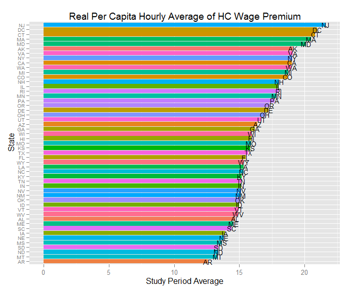

```r
print(Mean_Plot)
```

The same function could be used to plot a barplot of the growth rate found in the paper. In the paper, the geometric growth rate is used. To compute the geometric growth rate, the average of the first three estimates are used as the initial value, and the average of the last three estimates are used as the end value.

## Construct a Map

An extended tutorial on how to construct maps can be found [here](http://flowingdata.com/2013/07/08/small-maps-and-grids/). In the paper, the maps constructed are based on three year moving average data.

The humcap package has three functions for constructing maps. The first function is unimap(), and takes a vector of states data (for example estimates for a given year) to plot a single map. The scond function is multimap(), and takes a matrix of states data to plot a frame of several small maps. The third function, hc_map(), is a wrapper function, that is, it plots a single map if a vector data is provided, and multiple maps if a matrix is provided.

Note: These functions require the packages maps, plyr, and mapproj.

### Illistration

```r
library(maps)   # To draw map
library(plyr)       # Data formatting
library(mapproj)
```

Example with a single vector.

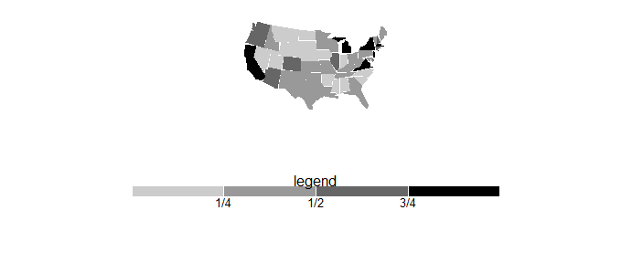

```r
hc_map(testmod2$All[,1]) # Plot a single map
```

Example with a matrix of data.

```r
smoothed_data <- smoother3(testmod2$All) #smooth the anual data first
hc_map(smoothed_data)
```

[figure not shown]

### CPI Data

The cpi data used are found [here](http://www.usinflationcalculator.com/inflation/consumer-price-index-and-annual-percent-changes-from-1913-to-2008/). The package come with prinstalled indexes from 1990 to 2013. In case you want to use data of after 2013, please copy the index vector [here](http://www.usinflationcalculator.com/inflation/consumer-price-index-and-annual-percent-changes-from-1913-to-2008/). It is imperative that you copy it starting from the year 1990. For instance, you can copy from 1990 to 2014, or 1990 to 2015, provided that the data are available. At the time of writing of these lines, 2015 data was not available. Just to repeat, the function requires a vector of indexes, which you can copy [here](http://www.usinflationcalculator.com/inflation/consumer-price-index-and-annual-percent-changes-from-1913-to-2008/). I use the annual averages column.

### Conclusion

This introduction aims at showing the reader how the functions in the humcap package could be used. Again, the package is written to make the replication of the “Human Capital Measurement: A Quantiles Regression Approach” paper easy. This introduction does not include the shiny app of the paper. The app codes are availlable uppon request sent to sbikienga@husker.unl.edu. Also, a nice tutorial on building shiny apps can be found [here](http://shiny.rstudio.com/).